# Analizë e ndikimit të turizmit në ekonominë shqiptare

Anisa Kapri

Andri Reveli

Dionis Hysko

2021-06-16

## Hyrje

Libraritë dhe paketat që do të përdoren në këtë projekt:

```r
library(ggplot2)
library(readxl)
library(dplyr)
library(R.utils)
```

```r
# Global constants
months = c("Janar", "Shkurt", "Mars", "Prill", "Maj", "Qershor", "Korrik", "Gusht",
           "Shtator", "Tetor", "Nentor", "Dhjetor")

years2016_2021 = c(2016, 2017, 2018, 2019, 2020, 2021)

currencies = c("GBP", "USD", "EUR", "CHF")
```

### Motivim

Dihet tashmë që sektori i turizmit është një nga sektorët më me peshë në ekonominë e Shqipërisë. Sipas INSTAT, në periudhën 2016 - 2019 rritja reale e prodhimit të brendshëm bruto për sektorin e shërbimeve akomoduese dhe ushqimore ka qenë 14% për çdo vit ose e thënë ndryshe për një periudhë 3 vjeçare ka patur një rritje me gati 48% PBB-së së këtij sektori. Kjo dëshmon fare mirë për rëndësinë e këtij sektori dhe studime të mëtejshme do të duhen ndërmarre duke vlerësuar këtë ecuri tepër pozitive.

Ky projekt synon të studiojë disa variabla të rëndesishmë sektorit të turizmit si: hyrje-daljet në Republikën e Shqipërisë vlerësuar sipas shtetësisë së vizitorëve dhe periudhës kur ata zgjedhin ta vizitojnë për qëllime turizmi dhe ndikimit që kjo lëvizje mund të ketë në kursin e këmbimit valutor, parë kjo për disa valuta kryesore.

Nga ana tjetër, ky projekt nuk synon të japë një përgjigje shteruese për variblat e marrë në shqyrtim, por as edhe të japë një vështrim sipërfaqësor. Të gjthë analizat edhe grafikët do të shoqërohen me komentin përkatës.

### Hyrje

Periudha 2014 - 2012 ka qenë periudha kur Instituti i Statistikave ka rishqyrtuar fokusin që sektori i turizmit duhet të ketë në publikimet dhe studimet e tij, duke pasuruar databazat dhe duke na venë në dispozicion më shumë të dhëna për të marrë në studim. Kjo na ka lejuar për të dhënë një pasqyrë tepër të mirë për të vëzhguar nga një pikëpamje ekonomike edhe statistike ecurinë e këtij sektori.

```r
# read the data
hyrje_dalje_vjetore = read_excel(
    path = "datasets/hyrje-dalje-vjetore.xlsx",
    col_types = c("numeric", "numeric", "numeric", "text")
)

print(hyrje_dalje_vjetore)
```

| Viti | Hyrje (total) | Dalje (total) | Shtetas |
| --- | --- | --- | --- |
| 2014 | 3872010 | 4145608 | Shqiptare |
| 2014 | 3672591 | 3675196 | Te huaj |
| 2015 | 4098526 | 4503907 | Shqiptare |
| 2015 | 4131242 | 4182918 | Te huaj |
| 2016 | 4592503 | 4852483 | Shqiptare |
| 2016 | 4735511 | 4668813 | Te huaj |
| 2017 | 4851622 | 5186100 | Shqiptare |
| 2017 | 5117700 | 5233380 | Te huaj |
| 2018 | 5319717 | 5415071 | Shqiptare |
| 2018 | 5926803 | 6017450 | Te huaj |

[output cut: 4 more lines]

```r
NA
```

Referencë [tabela e hyrje-daljeve vjetore](http://instat.gov.al/media/7951/tab-2.xlsx).

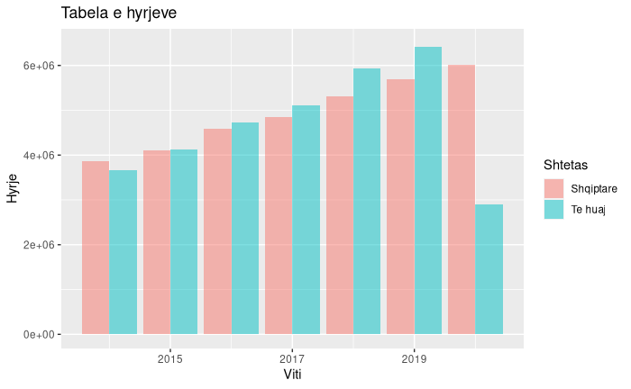

```r
ggplot(
    hyrje_dalje_vjetore,
    aes(x = Viti, y = `Hyrje (total)`, fill = Shtetas)
) +
    geom_bar(stat="identity",position = "dodge", alpha = 0.5) +
    labs(y = "Hyrje", title = "Tabela e hyrjeve") +
    coord_cartesian(ylim = c(0, 6500000))
```

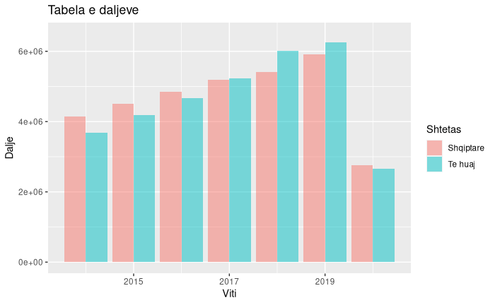

```r
ggplot(
    hyrje_dalje_vjetore,
    aes(x = Viti, y = `Dalje (total)`, fill = Shtetas)
) +
    geom_bar(stat="identity",position = "dodge", alpha = 0.5) +
    labs(y = "Dalje", title = "Tabela e daljeve") +
    coord_cartesian(ylim = c(0, 6500000))
```

```r
alb = hyrje_dalje_vjetore %>%
    filter(Shtetas == "Shqiptare")

foreign = hyrje_dalje_vjetore %>%
    filter(Shtetas == "Te huaj")

cv_hyrje_alb = 100 * sd(alb$`Hyrje (total)`) / mean(alb$`Hyrje (total)`)
cv_hyjre_foreign = 100 * sd(foreign$`Hyrje (total)`) / mean(foreign$`Hyrje (total)`)

printf("Varësia ndaj hyrjeve të shqiptarëve \t%g%%\n", cv_hyrje_alb)
```

```
Varësia ndaj hyrjeve të shqiptarëve     16.2854%
```

```r
printf("Varësia ndaj hyrjeve të të huajve \t%g%%\n", cv_hyjre_foreign)
```

```
Varësia ndaj hyrjeve të të huajve   26.3287%
```

#### Analiza e hyrjeve te shtetasve te huaj ne Shqipëri

Megjithëse, siç e përcaktuam më lartë që diaspora shqiptare është një kategori e sigurt, e cila do ta vizitojë Shqipërinë, nuk duhen neglizhuar turistët e huaj. Vërtetë diaspora shqiptare sa vjen edhe rritet, por numri i saj është relativisht i vogël kur e krahasojmë me potencialin për të sjellë turistë nga vende me popullsi të lartë dhe me pak akses në sezonin turistik veror si vendet e Europës nordike, qëndrore dhe lindore. Gjithashtu ia vlenë të kemi edhe një pamje më të mirë mbi cilin muaj të vitit tentojmë të kemi fluks hyrjesh nga turistët e huaj.

```r
hyrje_mujore_te_huaj = read_excel(
    path = "datasets/hyrje-mujore-te-huaj.xlsx",
    col_types = c("numeric", "numeric", "numeric")
)

print(hyrje_mujore_te_huaj)
```

| Vlera | Viti | Muaji |
| --- | --- | --- |
| 196814 | 2016 | 11 |
| 205166 | 2016 | 12 |
| 161145 | 2017 | 1 |
| 175257 | 2017 | 2 |
| 227709 | 2017 | 3 |
| 334164 | 2017 | 4 |
| 337109 | 2017 | 5 |
| 414529 | 2017 | 6 |
| 825652 | 2017 | 7 |
| 1116592 | 2017 | 8 |

[output cut: 42 more lines]

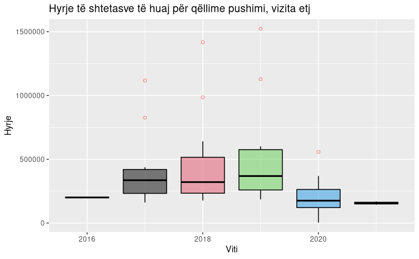

```r
ggplot(hyrje_mujore_te_huaj, aes(x = Viti, y = Vlera, group = Viti)) +
    geom_boxplot(
        outlier.colour = "red",
        outlier.shape = 1,
        alpha = 0.5,
        color = "black",
        fill = years2016_2021
    ) +
    labs(
        title = "Hyrje të shtetasve të huaj për qëllime pushimi, vizita etj",
        x = "Viti",
        y = "Hyrje"
    )
```

Referencë [hyrje te shtetasve te huaj](http://instat.gov.al/media/8157/tab-4.xlsx).

Ky grafik duket qartazi që është në mbështetje të grafikut të mësipërm, pra rritja e fluksit të hyrjeve të shtetasve të huaj në Republikën e Shqipërisë nuk ka qenë thjeshtë një tranzit i përkohshëm me qëllim hyrjen në ndonjë shtet fqinj, por kjo rritje i detyrohet shtimit të turistëve me shtetësi të huaj. Gjithashtu vihet re se kemi shumë pika “outlier” që i korrespondojnë muajve të verës dhe në përgjithësi vëzhgimet janë të mënjanuara në të djathtë.

**Shënim**: Vitiet 2016 dhe 2021 kanë shumë pak të dhëna, vetëm 2 muaj saktësisht.

Të dhënat mujore

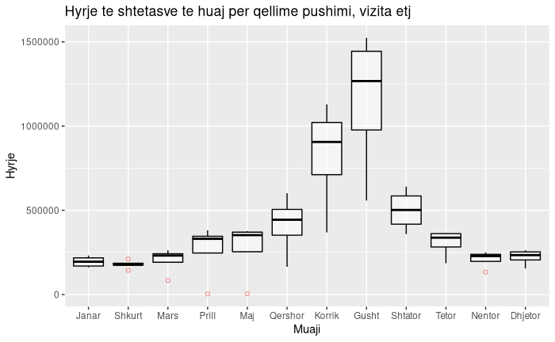

```r
ggplot(hyrje_mujore_te_huaj, aes(x = Muaji, y = Vlera, group = Muaji)) +
    geom_boxplot(outlier.colour = "red", outlier.shape = 1, alpha = 0.5, color = "black") +
    labs(
        title = "Hyrje te shtetasve te huaj per qellime pushimi, vizita etj",
        x = "Muaji",
        y = "Hyrje"
    ) +
    scale_x_discrete(
        limit = factor(1:12),
        labels = months
    )
```

Këtu vihet re akoma më mirë ndikimi që sezoni turistik veror ka në të vërtetë. Hyrjet e shtetasve fillojnë që të rriten në mënyrë të konsiderueshme në muajin qershor dhe në 2 muajt pasues kemi një shtim thuajse eksponencial të turistëve të huaj. Ia vlen të theksojmë se ekziston njëfare simetrie në qoftë se përjashtojmë muajt korrik edhe gusht. Vihet re se qershori edhe shtatori kanë një fluks të ngjashëm turizmi. I njëjti fluks shihet në prill, maj, tetor, por edhe në muaj me mot të ftohtë nëntor - mars. Kjo dëshmon fare mirë se turizmi në Shqipëri është përqëndruar vetëm në sezonin veror edhe muajt e fluksit nuk janë në nivele jo të krahasueshme. Mund të shtojmë si rekomandim, se në pamje të parë ekziston një potencial për zgjatjen me 2 muaj të sezonit turistik, më saktësisht në qershor edhe shtator. Politikat e qeverisë qëndrore dhe të bashkive bregdetare (Saranda, Vlora, Durrësi, Kavaja, Lezha) mund të fokusohen për nxitje të turizmit në muajt në fjalë,POR këtu nuk përjashtohen edhe operatorët turistik që të nxisin turistët e huaj për të vizituar Shqipërinë gjatë këtyre muajve me paketat e tyre turistike.

## Ndikimi i hyrjeve të shtetasve të huaj në kursin e këmbimit valutor

### Motivim

Nga analiza e mësiperme vumë re se ekziston një trend rritës i turistëve të huaj, po ashtu se hyrjet e tyre nuk janë të shpërndara në mënyrë të njëtrajtshme gjatë gjithë vitit, por ekziston një sezonalitet. Kjo na nxit interesin të shikojmë në qoftë se ka edhe rritje të shpenzimeve të këtyre turistëve. Fatkeqësisht nuk ekziston ndonjë databazë që të na japë një përgjigje “të lehtë” për sa i përketë të dhënave të shpenzimeve individuale për secilin turist, por kjo nuk na pengon ta analizojmë bazuar në disa faktorë shoqërues. Nga parimet bazë të ekonomisë, dimë se rritja e sasisë së një valute në treg sjell rëniën e vlerës së saj. Prandaj kemi zgjedhur të marrim në shqyrtim disa valuta kryesore si paundi britanik (GBP), euro (EUR), dollari amerikan (USD) dhe franga zviceriane (CHF).

### Analiza

```r
kursi_i_kembimit_valutor_mujor = read_excel(
    path = "datasets/kursi-i-kembimit-valutor-mujor.xlsx",
    col_types = c("text", "numeric", "numeric", "numeric")
)
print(kursi_i_kembimit_valutor_mujor)
```

| Monedha | Vlera (ALL) | Viti | Muaji |
| --- | --- | --- | --- |
| GBP | 156 | 2016 | 11 |
| CHF | 127 | 2016 | 11 |
| EUR | 136 | 2016 | 11 |
| USD | 126 | 2016 | 11 |
| GBP | 160 | 2016 | 12 |
| CHF | 126 | 2016 | 12 |
| EUR | 135 | 2016 | 12 |
| USD | 128 | 2016 | 12 |
| GBP | 158 | 2017 | 1 |
| CHF | 127 | 2017 | 1 |

[output cut: 198 more lines]

[figure not shown]

```r
ggplot(kursi_i_kembimit_valutor_mujor, aes(x = Muaji, y = `Vlera (ALL)`, group = Muaji)) +
    geom_boxplot(outlier.colour = "red", outlier.shape = 1, alpha = 0.5, color = "black") +
    labs(
        title = "Hyrje të shtetasve të huaj për qëllime pushimi, vizita etj",
        x = "Muaji",
        y = "Hyrje"
    ) +
    facet_wrap(vars(Monedha))
```

Në pamje të parë shihet një rënie gjatë muajit të 5-të deri në muajin e 10-të të vitit në përgjithësi për të gjitha valutat. Në përgjithësi GBP duket më e ndjeshme ndaj këtij ndryshimi.

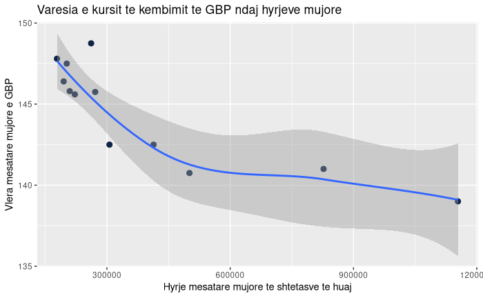

```r
# mean of foreign tourists per each month of the year
x = hyrje_mujore_te_huaj %>%
    group_by(Muaji) %>%
    summarise_at(
        vars(Vlera),
        list(name = mean)
    )

# mean of exchange rate of each currency per each month of the year
monedha = data.frame(months)
for (curr in currencies) {
    el = kursi_i_kembimit_valutor_mujor %>%
    filter(Monedha == curr) %>%
    group_by(Muaji) %>%
    summarise_at(
        vars(`Vlera (ALL)`),
        list(name = mean)
    )
    monedha[curr] = el$name
}

# combine
df = data.frame(
    muaji = months,
    hyrje = x$name,
    gbp = monedha$GBP,
    chf = monedha$CHF,
    eur = monedha$EUR,
    usd = monedha$USD
)

# gbp
ggplot(df) +
    aes(x = hyrje, y = gbp) +
    geom_point(
        shape = "circle",
        size = 2.5,
        colour = "#112446"
    ) +
    geom_smooth(span = 1L) +
    labs(
        x = "Hyrje mesatare mujore te shtetasve te huaj",
        y = "Vlera mesatare mujore e GBP",
        title = "Varesia e kursit te kembimit te GBP ndaj hyrjeve mujore"
    ) +
    theme_gray()
```

```r
cor.test(x = df$hyrje, y = df$gbp)
```

```
    Pearson's product-moment correlation

data:  df$hyrje and df$gbp
t = -4.7504, df = 10, p-value = 0.0007797
alternative hypothesis: true correlation is not equal to 0
95 percent confidence interval:
 -0.9516814 -0.4950083
sample estimates:
       cor
-0.8324285
```

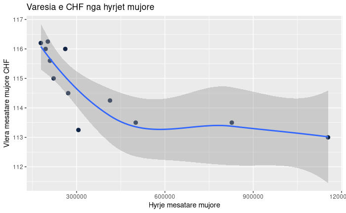

```r
# chf
ggplot(df) +
    aes(x = hyrje, y = chf) +
    geom_point(shape = "circle", size = 2.5, colour = "#112446") +
    geom_smooth(span = 1L) +
    labs(
        x = "Hyrje mesatare mujore",
        y = "Vlera mesatare mujore CHF",
        title = "Varesia e CHF nga hyrjet mujore"
    ) +
    theme_gray()
```

```r
cor.test(x = df$hyrje, y = df$chf)
```

```
    Pearson's product-moment correlation

data:  df$hyrje and df$chf
t = -3.5016, df = 10, p-value = 0.005711
alternative hypothesis: true correlation is not equal to 0
95 percent confidence interval:
 -0.9229489 -0.2930785
sample estimates:
       cor
-0.7421515
```

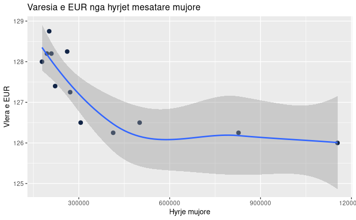

```r
# eur
ggplot(df) +
    aes(x = hyrje, y = eur) +
    geom_point(shape = "circle", size = 2.5, colour = "#112446") +
    geom_smooth(span = 1L) +
    labs(
        x = "Hyrje mujore",
        y = "Vlera e EUR",
        title = "Varesia e EUR nga hyrjet mesatare mujore"
    ) +
    theme_gray()
```

```r
cor.test(x = df$hyrje, y = df$eur)
```

```
    Pearson's product-moment correlation

data:  df$hyrje and df$eur
t = -3.511, df = 10, p-value = 0.005622
alternative hypothesis: true correlation is not equal to 0
95 percent confidence interval:
 -0.9232438 -0.2948998
sample estimates:
       cor
-0.7430458
```

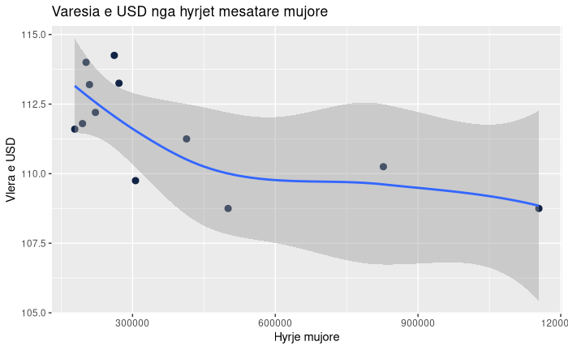

```r
# usd
ggplot(df) +
    aes(x = hyrje, y = usd) +
    geom_point(shape = "circle", size = 2.5, colour = "#112446") +
    geom_smooth(span = 1L) +
    labs(
        x = "Hyrje mujore",
        y = "Vlera e USD",
        title = "Varesia e USD nga hyrjet mesatare mujore"
    ) +
    theme_gray()
```

```r
cor.test(x = df$hyrje, y = df$usd)
```

```
    Pearson's product-moment correlation

data:  df$hyrje and df$usd
t = -2.9814, df = 10, p-value = 0.01378
alternative hypothesis: true correlation is not equal to 0
95 percent confidence interval:
 -0.9039963 -0.1848687
sample estimates:
       cor
-0.6859893
```

### Përfundime

Në testet e mësiperme për secilën prej valutave është marrë mesatarja mujore, bazuar në të dhënat e marra nga Banka e Shqipërisë dhe është krahasuar përkundrejt mesatares së hyrjeve mujore të turistëve të huaj duke përdorur testin e korrelacionit të Pirsonit.

[output not shown]

E thënë ndryshe, vlera e kursit të këmbimit të GBP-së është shumë më e ndjeshme ndaj sezonit krahasuar me valutat e tjera, kurse USD-ja ndikohet më pak nga të gjthë monedhat e tjera, por gjithsesi mbetet në nivele të krahasueshme me EUR dhe CHF.

Duke e parë nga një këndvështrim ekonomik, drejtëza rënëse që shohim për vlera < 600.000 turistë të huaj mesatarisht në muaj është dicka e pritshme, sic e shprehëm në hyrjen e këtij seksioni. Ky rezultat mbështet hipotezën se shtimi i hyrjeve të turistëve të huaj ka sjellë shtimin e valutave të huaja në tregun shqiptar, që interpretohet si rritje e konsumit e shkaktuar prej sezonit turistik.

Referencë [kursi i kembimit valutor](https://www.bankofalbania.org/Statistikat/Statistikat_e_Sektorit_te_Jashtem/Kursi_i_kembimit/Kursi_mesatar_mujor.html).

## Vlerësimi i netëve të qëndrimit sipas tremujorve

### Motivim

Një ndër elementët që na intereson të ndërtojmë, është një interval besimi për netët e qëndrimit që një turist shqiptar apo i huaj qëndron në një hotel, pasi kjo mund të shërbejë si një metodë për të ditur se sa netë nj!turist mund të shpenzojë mesatarisht në Shqiperi. Më poshtë janë vendosur të dhënat se sa netë pushuesit kanë shpenzuar në hotelet shqiptare çdo tremujor nga viti 2018 deri në trejmuojrin e parë të 2021.

```r
nete_qendrimi <- read_excel("~/projects/applied-statistics/datasets/nete-qendrimi.xlsx",
    col_types = c("text", "numeric", "numeric",
        "numeric"))

print(nete_qendrimi)
```

| statusi | numri | tremujori | viti |
| --- | --- | --- | --- |
| rezident | 95134 | 1 | 2018 |
| jorezident | 94652 | 1 | 2018 |
| rezident | 220894 | 2 | 2018 |
| jorezident | 516325 | 2 | 2018 |
| rezident | 452193 | 3 | 2018 |
| jorezident | 1330698 | 3 | 2018 |
| rezident | 162969 | 4 | 2018 |
| jorezident | 201792 | 4 | 2018 |
| rezident | 96953 | 1 | 2019 |
| jorezident | 98724 | 1 | 2019 |

[output cut: 16 more lines]

```r
interval = function(vec) {
    students = 0
    n = length(vec)

    if (n == 3) {
        students = 4.303
    }
    else if (n == 4) {
        students = 3.182
    }

    m = mean(vec)
    s = sd(vec)

    v1 = m - students * s / n
    v2 = m + students * s / n
    return(c(v1, v2))
}

for (i in 1:4) {
    tremujori_i = nete_qendrimi %>%
        filter(tremujori == i)

    rezident = tremujori_i %>%
        filter(statusi == "rezident")

    jorezident = tremujori_i %>%
        filter(statusi == "jorezident")

    ir = interval(rezident$numri)
    ij = interval(jorezident$numri)

    printf("%g)\trezident:\t[%-7.0f - %7.0f]\n", i, ir[1], ir[2])
    printf("\tjorezident:\t[%-7.0f - %7.0f]\n", ij[1], ij[2])
}
```

```
1)  rezident:   [91048   -  102472]
    jorezident: [74430   -   95959]
2)  rezident:   [91359   -  256939]
    jorezident: [-43916  -  689329]
3)  rezident:   [431399  -  548224]
    jorezident: [477615  - 1784921]
4)  rezident:   [49140   -  314187]
    jorezident: [73801   -  240803]
```

### Përfundime

**Shënim**: Intervali i besimit për jorezidentët në tremujorin e dytë merr vlerë negative prej të dhënave të tremujorit të dytë 2020. Siç dihet kufizimet e pandemisë kufizuan hyrjet në Shqipëri dhe kjo shkakton që testi statistikor për këtë vëzhgim të marri vlerë të palejuar. Gjithashtu në vitin 2020, siç u pa edhe në grafikun nr.1, pati shumë herë më pak turistë të huaj gjë që shkakton luhatje të mëdha për kategorinë jorezident.

Referencë nete qendrimi

## Përfundime dhe rekomandime

Për vendin tonë, dimë fare mirë që një ndër faktorët, të cilët ndikojnë në zhvillimin e ekonomisë shqiptare është sektori I turizmit dhe ka një potencial të lartë për t’u rritur në vitet e ardhshme për shkak të të gjithë atraksioneve apo mundësive që vendi ynë ofron, duke bërë në këtë mënyrë që Shqipëria të ofrojë lloje të ndryshme turizmi (bregdetar, malor, historik, shëndetsor).

Duhet theksuar se një zbulim tepër interesant i këtij projekti është besnikëria që pushuesit me shtetesi shqiptare kanë për te pushuar në Shqipëri. Ky projekt në te dhënat që ka shfrytëzuar ka përfshirë në një pjesë t! konsiderueshme të dhëna nga viti 2020 - 2021. Megjithëse në këtë periudhë Shqipëria ka patur kufizime në lëvizjen e lirë, gjë që është reflektuar në numrin e turistëve te huaj, turistët Shqiptarë kanë pësuar rritje me një ritëm të ngjashëm sikurse para pandemisë.

## Referencat

1. http://instat.gov.al/media/8157/tab-4.xlsx
2. [http://instat.gov.al/media/8157/tab-2.xlsx](http://instat.gov.al/media/7951/tab-2.xlsx)
3. https://www.bankofalbania.org/Statistikat/Statistikat_e_Sektorit_te_Jashtem/Kursi_i_kembimit/Kursi_mesatar_mujor.html
4. instat.gov.al/media/8287/tab-3.xlsx
5. instat.gov.al/media/8381/t1_2021-tab_2_net%C3%AB-q%C3%ABndrime.xlsx